# R code for CAG 2021 paper

```r
library(knitr)
library(rmdformats)
library(ROCR)
require(ggplot2)
library(ModelMetrics)
library(rsample)
library(boot)
library(knitr)
require(xlsx)
```

This file provides some of the code used to generate several results presented in the paper:

```
Model for predicting perception of facial action unit activation using virtual humans

by R. McDonnell, E. Carrigan, K. Zibrek, and R. Dahyot accepted   to Computer and Graphics in 2021.
```

with Github repo https://github.com/Roznn/facial-blendshapes that is also hosting the code for an earlier version of this work published in ACM MIG 2020.

Results for some models reported in the paper (e.g. AICs, Deviance) have been run in the R Console directly and are not in the Example Rmd code but can easily be inferred from the example code given. Please read the paper for more information on the meaning of the variables and meaning of results shown.

**Please cite the paper when using data and/or code.**

The data (Experiment 1: Laboratory) is loaded as follows:

```r
mydata =read.xlsx("combined_resultsUpdate.xlsx", sheetName = "combined")
```

# AIC and Deviance (CAG2021 paper: Tab. 3)

Note: some results reported in the paper are sometimes directly read from the output of the function `glm` and may differ by a few non significative digit from the ones computed here with the function `AIC`for instance. This is illustrated in the first example with *Activation* as explanatory variable in the model for response variable *Difference*.

## Activation

### Activation

```r
mg <- glm(Difference~Activation ,data=mydata,family=gaussian(link="identity"))
mg
```

```
Call:  glm(formula = Difference ~ Activation, family = gaussian(link = "identity"),
    data = mydata)

Coefficients:
(Intercept)   Activation
      1.438        3.099

Degrees of Freedom: 7199 Total (i.e. Null);  7198 Residual
Null Deviance:      31600
Residual Deviance: 26070    AIC: 29700
```

```r
# note the output for AIC is 29700 as reported in the paper
mp <- glm(Difference~Activation ,data=mydata,family=poisson(link="identity"))
mp
```

```
Call:  glm(formula = Difference ~ Activation, family = poisson(link = "identity"),
    data = mydata)

Coefficients:
(Intercept)   Activation
      1.412        3.144

Degrees of Freedom: 7199 Total (i.e. Null);  7198 Residual
Null Deviance:      9388
Residual Deviance: 7650     AIC: 28440
```

```r
# note the output for AIC is 28440 as reported in the paper

# Now below displaying these AICs with better precision provide slightly different numbers

kable(AIC(mg,mp))
```

|  | df | AIC |
| --- | --- | --- |
| mg | 3 | 29703.40 |
| mp | 2 | 28444.39 |

```r
deviance(mp)
```

```
[1] 7650.282
```

```r
qchisq(0.95, length(mydata$Difference)-length(mp$coefficient))
```

```
[1] 7396.485
```

### Activation*AU

```r
mg <- glm(Difference~Activation *AU_Name,data=mydata,family=gaussian(link="identity"))
mp <- glm(Difference~Activation *AU_Name,data=mydata,family=poisson(link="identity"))

kable(AIC(mg,mp))
```

|  | df | AIC |
| --- | --- | --- |
| mg | 25 | 24880.39 |
| mp | 24 | 24690.88 |

```r
deviance(mp)
```

```
[1] 3852.767
```

```r
qchisq(0.95, length(mydata$Difference)-length(mp$coefficient))
```

```
[1] 7374.184
```

### Activation *AU + Race : Sex

```r
mp <- glm(Difference~Activation *AU_Name+Race:Sex,data=mydata,family=poisson(link="identity"))
mg <- glm(Difference~Activation *AU_Name+Race:Sex,data=mydata,family=gaussian(link="identity"))



kable(AIC(mg,mp))
```

|  | df | AIC |
| --- | --- | --- |
| mg | 30 | 24855.14 |
| mp | 29 | 24675.45 |

```r
deviance(mp)
```

```
[1] 3827.34
```

```r
qchisq(0.95, length(mydata$Difference)-length(mp$coefficient))
```

```
[1] 7368.101
```

### Activation * AU * Race * Sex

```r
mp <- glm(Difference~Activation *AU_Name*Race*Sex,data=mydata,family=poisson(link="identity"))
mg <- glm(Difference~Activation *AU_Name*Race*Sex,data=mydata,family=gaussian(link="identity"))

kable(AIC(mg,mp))
```

|  | df | AIC |
| --- | --- | --- |
| mg | 145 | 24820.55 |
| mp | 144 | 24759.12 |

```r
deviance(mp)
```

```
[1] 3681.008
```

```r
qchisq(0.95, length(mydata$Difference)-length(mp$coefficient))
```

```
[1] 7252.529
```

## STED

### STED

```r
mg <- glm(Difference~STED,data=mydata,family=gaussian(link="identity"))
mp <- glm(Difference~STED,data=mydata,family=poisson(link="identity"))

kable(AIC(mg,mp))
```

|  | df | AIC |
| --- | --- | --- |
| mg | 3 | 28704.83 |
| mp | 2 | 27345.97 |

```r
deviance(mp)
```

```
[1] 6551.857
```

```r
qchisq(0.95, length(mydata$Difference)-length(mp$coefficient))
```

```
[1] 7396.485
```

### STED*AU

```r
mg <- glm(Difference~STED*AU_Name,data=mydata,family=gaussian(link="sqrt"))
mp <- glm(Difference~STED*AU_Name,data=mydata,family=poisson(link="sqrt"))

kable(AIC(mg,mp))
```

|  | df | AIC |
| --- | --- | --- |
| mg | 24 | 24850.90 |
| mp | 23 | 24680.13 |

```r
deviance(mp)
```

```
[1] 3844.015
```

```r
qchisq(0.95, length(mydata$Difference)-length(mp$coefficient))
```

```
[1] 7374.184
```

### STED*AU + Race : Sex

```r
mp <- glm(Difference~STED*AU_Name+Race:Sex,data=mydata,family=poisson(link="sqrt"))
mg <- glm(Difference~STED*AU_Name+Race:Sex,data=mydata,family=gaussian(link="sqrt"))



kable(AIC(mg,mp))
```

|  | df | AIC |
| --- | --- | --- |
| mg | 29 | 24832.20 |
| mp | 28 | 24669.76 |

```r
deviance(mp)
```

```
[1] 3823.648
```

```r
qchisq(0.95, length(mydata$Difference)-length(mp$coefficient))
```

```
[1] 7368.101
```

### STED* AU * Race * Sex

```r
mp <- glm(Difference~STED*AU_Name*Race*Sex,data=mydata,family=poisson(link="sqrt"))
mg <- glm(Difference~STED*AU_Name*Race*Sex,data=mydata,family=gaussian(link="sqrt"))

kable(AIC(mg,mp))
```

|  | df | AIC |
| --- | --- | --- |
| mg | 139 | 24781.44 |
| mp | 138 | 24742.48 |

```r
deviance(mp)
```

```
[1] 3676.371
```

```r
qchisq(0.95, length(mydata$Difference)-length(mp$coefficient))
```

```
[1] 7252.529
```

## RMS

### RMS

```r
mg <- glm(Difference~RMS,data=mydata,family=gaussian(link="identity"))
mp <- glm(Difference~RMS,data=mydata,family=poisson(link="identity"))

kable(AIC(mg,mp))
```

|  | df | AIC |
| --- | --- | --- |
| mg | 3 | 27965.04 |
| mp | 2 | 26903.50 |

```r
deviance(mp)
```

```
[1] 6109.388
```

```r
qchisq(0.95, length(mydata$Difference)-length(mp$coefficient))
```

```
[1] 7396.485
```

### RMS*AU

```r
mg <- glm(Difference~RMS*AU_Name,data=mydata,family=gaussian(link="identity"))
mp <- glm(Difference~RMS*AU_Name,data=mydata,family=poisson(link="identity"))

kable(AIC(mg,mp))
```

|  | df | AIC |
| --- | --- | --- |
| mg | 24 | 24878.39 |
| mp | 23 | 24688.88 |

```r
deviance(mp)
```

```
[1] 3852.773
```

```r
qchisq(0.95, length(mydata$Difference)-length(mp$coefficient))
```

```
[1] 7374.184
```

### RMS*AU + Race : Sex

```r
mp <- glm(Difference~RMS*AU_Name+Race:Sex,data=mydata,family=poisson(link="identity"))
mg <- glm(Difference~RMS*AU_Name+Race:Sex,data=mydata,family=gaussian(link="identity"))

kable(AIC(mg,mp))
```

|  | df | AIC |
| --- | --- | --- |
| mg | 29 | 24853.14 |
| mp | 28 | 24673.46 |

```r
deviance(mp)
```

```
[1] 3827.344
```

```r
qchisq(0.95, length(mydata$Difference)-length(mp$coefficient))
```

```
[1] 7368.101
```

### RMS* AU * Race * Sex

```r
mp <- glm(Difference~RMS*AU_Name*Race*Sex,data=mydata,family=poisson(link="identity"))
mg <- glm(Difference~RMS*AU_Name*Race*Sex,data=mydata,family=gaussian(link="identity"))

kable(AIC(mg,mp))
```

|  | df | AIC |
| --- | --- | --- |
| mg | 139 | 24810.65 |
| mp | 138 | 24749.68 |

```r
deviance(mp)
```

```
[1] 3683.565
```

```r
qchisq(0.95, length(mydata$Difference)-length(mp$coefficient))
```

```
[1] 7252.529
```

## SSIM

### SSIM

```r
mg <- glm(Difference~SSIM,data=mydata,family=gaussian(link="identity"))
mp <- glm(Difference~SSIM,data=mydata,family=poisson(link="identity"))

kable(AIC(mg,mp))
```

|  | df | AIC |
| --- | --- | --- |
| mg | 3 | 29534.91 |
| mp | 2 | 28074.83 |

```r
deviance(mp)
```

```
[1] 7280.717
```

```r
qchisq(0.95, length(mydata$Difference)-length(mp$coefficient))
```

```
[1] 7396.485
```

### SSIM*AU

```r
mg <- glm(Difference~SSIM*AU_Name,data=mydata,family=gaussian(link="identity"))
mp <- glm(Difference~SSIM*AU_Name,data=mydata,family=poisson(link="identity"))

kable(AIC(mg,mp))
```

|  | df | AIC |
| --- | --- | --- |
| mg | 25 | 26287.12 |
| mp | 24 | 25591.53 |

```r
deviance(mp)
```

```
[1] 4753.421
```

```r
qchisq(0.95, length(mydata$Difference)-length(mp$coefficient))
```

```
[1] 7374.184
```

### SSIM*AU + Race : Sex

```r
mp <- glm(Difference~SSIM*AU_Name+Race:Sex,data=mydata,family=poisson(link="log"))
mg <- glm(Difference~SSIM*AU_Name+Race:Sex,data=mydata,family=gaussian(link="sqrt"))

kable(AIC(mg,mp))
```

|  | df | AIC |
| --- | --- | --- |
| mg | 30 | 25505.00 |
| mp | 29 | 25112.26 |

```r
deviance(mp)
```

```
[1] 4264.153
```

```r
qchisq(0.95, length(mydata$Difference)-length(mp$coefficient))
```

```
[1] 7368.101
```

### SSIM* AU * Race * Sex

```r
mp <- glm(Difference~SSIM*AU_Name*Race*Sex,data=mydata,family=poisson(link="log"))
mg <- glm(Difference~SSIM*AU_Name*Race*Sex,data=mydata,family=gaussian(link="sqrt"))

kable(AIC(mg,mp))
```

|  | df | AIC |
| --- | --- | --- |
| mg | 145 | 24798.87 |
| mp | 144 | 24758.75 |

```r
deviance(mp)
```

```
[1] 3680.642
```

```r
qchisq(0.95, length(mydata$Difference)-length(mp$coefficient))
```

```
[1] 7252.529
```

## MSE

### MSE

```r
mg <- glm(Difference~MSE,data=mydata,family=gaussian(link="identity"))
mp <- glm(Difference~MSE,data=mydata,family=poisson(link="identity"))

kable(AIC(mg,mp))
```

|  | df | AIC |
| --- | --- | --- |
| mg | 3 | 29920.07 |
| mp | 2 | 28678.49 |

```r
deviance(mp)
```

```
[1] 7884.374
```

```r
qchisq(0.95, length(mydata$Difference)-length(mp$coefficient))
```

```
[1] 7396.485
```

### MSE*AU

```r
mg <- glm(Difference~MSE*AU_Name,data=mydata,family=gaussian(link="log"))
mp <- glm(Difference~MSE*AU_Name,data=mydata,family=poisson(link="log"))

kable(AIC(mg,mp))
```

|  | df | AIC |
| --- | --- | --- |
| mg | 25 | 26939.79 |
| mp | 24 | 26115.81 |

```r
deviance(mp)
```

```
[1] 5277.696
```

```r
qchisq(0.95, length(mydata$Difference)-length(mp$coefficient))
```

```
[1] 7374.184
```

### MSE*AU + Race : Sex

```r
mp <- glm(Difference~MSE*AU_Name+Race:Sex,data=mydata,family=poisson(link="identity"))
mg <- glm(Difference~MSE*AU_Name+Race:Sex,data=mydata,family=gaussian(link="identity"))

kable(AIC(mg,mp))
```

|  | df | AIC |
| --- | --- | --- |
| mg | 30 | 25933.64 |
| mp | 29 | 25384.25 |

```r
deviance(mp)
```

```
[1] 4536.134
```

```r
qchisq(0.95, length(mydata$Difference)-length(mp$coefficient))
```

```
[1] 7368.101
```

### MSE* AU * Race * Sex

```r
mp <- glm(Difference~MSE*AU_Name*Race*Sex,data=mydata,family=poisson(link="identity"))
mg <- glm(Difference~MSE*AU_Name*Race*Sex,data=mydata,family=gaussian(link="identity"))

kable(AIC(mg,mp))
```

|  | df | AIC |
| --- | --- | --- |
| mg | 145 | 24839.44 |
| mp | 144 | 24776.94 |

```r
deviance(mp)
```

```
[1] 3698.828
```

```r
qchisq(0.95, length(mydata$Difference)-length(mp$coefficient))
```

```
[1] 7252.529
```

# ANOVA tables (CAG2021 paper: Tab. 4-7)

## Using Geometric metrics

### RMS (Tab 4)

```r
kable(anova(lm(Difference~RMS * AU_Name*Race*Sex,data=mydata)))
```

|  | Df | Sum Sq | Mean Sq | F value | Pr(>F) |
| --- | --- | --- | --- | --- | --- |
| RMS | 1 | 11125.300638 | 11125.300638 | 6174.5318210 | 0.0000000 |
| AU_Name | 11 | 5114.028326 | 464.911666 | 258.0255554 | 0.0000000 |
| Race | 2 | 24.913623 | 12.456811 | 6.9135191 | 0.0010010 |
| Sex | 1 | 3.555549 | 3.555549 | 1.9733265 | 0.1601392 |
| RMS:AU_Name | 10 | 2103.488064 | 210.348806 | 116.7433978 | 0.0000000 |
| RMS:Race | 2 | 21.928141 | 10.964071 | 6.0850493 | 0.0022886 |
| AU_Name:Race | 22 | 132.014531 | 6.000661 | 3.3303612 | 0.0000002 |
| RMS:Sex | 1 | 7.984011 | 7.984011 | 4.4311190 | 0.0353246 |
| AU_Name:Sex | 11 | 30.062895 | 2.732991 | 1.5168072 | 0.1178373 |
| Race:Sex | 2 | 36.295358 | 18.147679 | 10.0719456 | 0.0000429 |
| RMS:AU_Name:Race | 20 | 63.216915 | 3.160846 | 1.7542666 | 0.0198763 |
| RMS:AU_Name:Sex | 10 | 10.545040 | 1.054504 | 0.5852488 | 0.8274277 |
| RMS:Race:Sex | 2 | 6.866608 | 3.433304 | 1.9054806 | 0.1488276 |
| AU_Name:Race:Sex | 22 | 140.943779 | 6.406535 | 3.5556214 | 0.0000000 |
| RMS:AU_Name:Race:Sex | 20 | 58.884299 | 2.944215 | 1.6340367 | 0.0368748 |
| Residuals | 7062 | 12724.345000 | 1.801805 | NA | NA |

### STED (Tab. 5)

```r
kable(anova(lm(Difference~STED * AU_Name*Race*Sex,data=mydata)))
```

|  | Df | Sum Sq | Mean Sq | F value | Pr(>F) |
| --- | --- | --- | --- | --- | --- |
| STED | 1 | 8.909196e+03 | 8909.1960284 | 4959.5269412 | 0.0000000 |
| AU_Name | 11 | 8.879785e+03 | 807.2531671 | 449.3776787 | 0.0000000 |
| Race | 2 | 2.751392e+01 | 13.7569583 | 7.6581551 | 0.0004761 |
| Sex | 1 | 6.007024e-01 | 0.6007024 | 0.3343960 | 0.5631004 |
| STED:AU_Name | 10 | 5.919195e+02 | 59.1919463 | 32.9506783 | 0.0000000 |
| STED:Race | 2 | 1.641944e+01 | 8.2097194 | 4.5701457 | 0.0103871 |
| AU_Name:Race | 22 | 1.166772e+02 | 5.3035089 | 2.9523310 | 0.0000043 |
| STED:Sex | 1 | 1.049386e+01 | 10.4938614 | 5.8416706 | 0.0156761 |
| AU_Name:Sex | 11 | 3.423820e+01 | 3.1125638 | 1.7326865 | 0.0602727 |
| Race:Sex | 2 | 2.600132e+01 | 13.0006601 | 7.2371428 | 0.0007247 |
| STED:AU_Name:Race | 20 | 6.507961e+01 | 3.2539803 | 1.8114095 | 0.0146421 |
| STED:AU_Name:Sex | 10 | 9.721461e+00 | 0.9721461 | 0.5411694 | 0.8619625 |
| STED:Race:Sex | 2 | 5.764906e+00 | 2.8824531 | 1.6045897 | 0.2010453 |
| AU_Name:Race:Sex | 22 | 1.655589e+02 | 7.5254024 | 4.1892036 | 0.0000000 |
| STED:AU_Name:Race:Sex | 20 | 5.936597e+01 | 2.9682986 | 1.6523777 | 0.0336347 |
| Residuals | 7062 | 1.268604e+04 | 1.7963802 | NA | NA |

## Using Image metrics

### SSIM (Tab. 6)

```r
kable(anova(lm(Difference~SSIM* AU_Name*Race*Sex,data=mydata)))
```

|  | Df | Sum Sq | Mean Sq | F value | Pr(>F) |
| --- | --- | --- | --- | --- | --- |
| SSIM | 1 | 6135.88301 | 6135.883010 | 3393.489386 | 0.0000000 |
| AU_Name | 11 | 8500.78006 | 772.798188 | 427.400986 | 0.0000000 |
| Race | 2 | 539.61982 | 269.809911 | 149.220099 | 0.0000000 |
| Sex | 1 | 279.76842 | 279.768416 | 154.727714 | 0.0000000 |
| SSIM:AU_Name | 11 | 924.91321 | 84.083019 | 46.502652 | 0.0000000 |
| SSIM:Race | 2 | 107.19315 | 53.596574 | 29.641928 | 0.0000000 |
| AU_Name:Race | 22 | 419.42216 | 19.064644 | 10.543823 | 0.0000000 |
| SSIM:Sex | 1 | 11.40373 | 11.403727 | 6.306904 | 0.0120490 |
| AU_Name:Sex | 11 | 489.92097 | 44.538270 | 24.632175 | 0.0000000 |
| Race:Sex | 2 | 645.40840 | 322.704198 | 178.473623 | 0.0000000 |
| SSIM:AU_Name:Race | 22 | 177.68390 | 8.076541 | 4.466783 | 0.0000000 |
| SSIM:AU_Name:Sex | 11 | 68.12323 | 6.193021 | 3.425090 | 0.0000914 |
| SSIM:Race:Sex | 2 | 148.00017 | 74.000085 | 40.926221 | 0.0000000 |
| AU_Name:Race:Sex | 22 | 297.96831 | 13.544014 | 7.490604 | 0.0000000 |
| SSIM:AU_Name:Race:Sex | 22 | 100.09184 | 4.549629 | 2.516202 | 0.0001106 |
| Residuals | 7056 | 12758.19241 | 1.808134 | NA | NA |

### MSE (Tab. 7)

```r
kable(anova(lm(Difference~MSE* AU_Name*Race*Sex,data=mydata)))
```

|  | Df | Sum Sq | Mean Sq | F value | Pr(>F) |
| --- | --- | --- | --- | --- | --- |
| MSE | 1 | 4.736388e+03 | 4736.3879475 | 2620.3425082 | 0.0000000 |
| AU_Name | 11 | 8.523976e+03 | 774.9068976 | 428.7067500 | 0.0000000 |
| Race | 2 | 5.997513e+02 | 299.8756275 | 165.9021310 | 0.0000000 |
| Sex | 1 | 3.300257e-01 | 0.3300257 | 0.1825822 | 0.6691765 |
| MSE:AU_Name | 11 | 2.162635e+03 | 196.6032101 | 108.7680643 | 0.0000000 |
| MSE:Race | 2 | 1.331603e+02 | 66.5801372 | 36.8345595 | 0.0000000 |
| AU_Name:Race | 22 | 1.098384e+03 | 49.9265635 | 27.6211953 | 0.0000000 |
| MSE:Sex | 1 | 1.379690e+02 | 137.9690345 | 76.3295004 | 0.0000000 |
| AU_Name:Sex | 11 | 1.264741e+02 | 11.4976458 | 6.3609169 | 0.0000000 |
| Race:Sex | 2 | 2.662114e+02 | 133.1057120 | 73.6389331 | 0.0000000 |
| MSE:AU_Name:Race | 22 | 5.476811e+02 | 24.8945964 | 13.7725984 | 0.0000000 |
| MSE:AU_Name:Sex | 11 | 1.361104e+02 | 12.3736730 | 6.8455670 | 0.0000000 |
| MSE:Race:Sex | 2 | 2.538023e+01 | 12.6901141 | 7.0206338 | 0.0008995 |
| AU_Name:Race:Sex | 22 | 1.233556e+02 | 5.6070706 | 3.1020359 | 0.0000014 |
| MSE:AU_Name:Race:Sex | 22 | 2.325258e+02 | 10.5693524 | 5.8473511 | 0.0000000 |
| Residuals | 7056 | 1.275404e+04 | 1.8075454 | NA | NA |

# Figures (CAG 2021 paper: Fig. 4)

## RMS*AU+Race:Sex (Fig.4 (a))

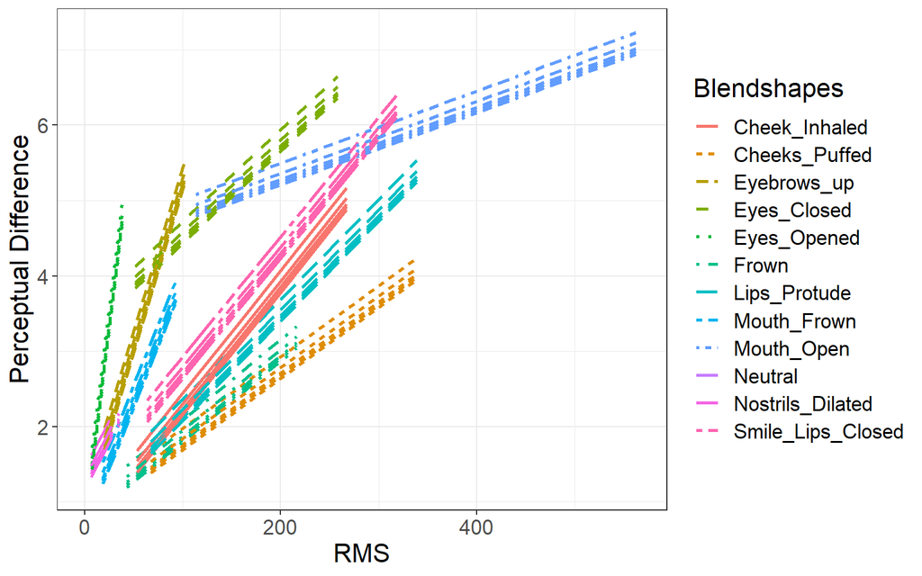

```r
m<-glm(Difference~RMS*relevel(factor(AU_Name),ref='Neutral')+Race:Sex,data=mydata,family=poisson(link="identity"))

ggplot(mydata,aes(RMS, Difference, group=interaction(AU_Name,Race,Sex), col=interaction(AU_Name),linetype=interaction(AU_Name)))+
   geom_line(aes(y=m$fitted.values, colour=AU_Name, linetype=AU_Name),size=1) +
   ylab("Perceptual Difference") +
   xlab("RMS") +
   theme_bw()+
   theme(text = element_text(size = 16))+
   labs(col="Blendshapes",linetype="Blendshapes")
```

## RMS*AU (Fig 4 (b))

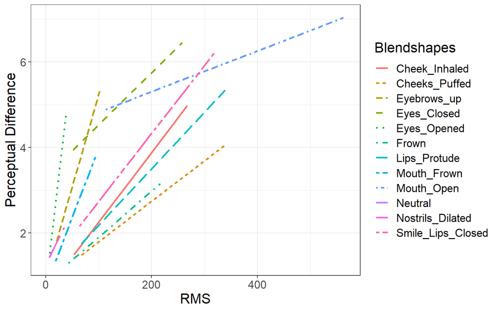

```r
m<-glm(Difference~RMS*relevel(factor(AU_Name),ref='Neutral'),data=mydata,family=poisson(link="identity"))

ggplot(mydata,aes(RMS, Difference, group=interaction(AU_Name), col=interaction(AU_Name),linetype=interaction(AU_Name)))+
   geom_line(aes(y=m$fitted.values, colour=AU_Name, linetype=AU_Name),size=1) +
   ylab("Perceptual Difference") +
   xlab("RMS") +
   theme_bw()+
   theme(text = element_text(size = 16))+
   labs(col="Blendshapes",linetype="Blendshapes")
```

## STED*AU+Race:Sex (Fig.4 (c))

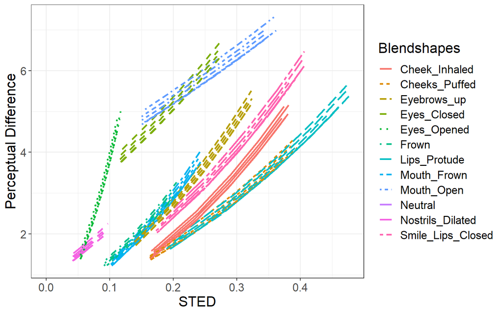

```r
m<-glm(Difference~STED*relevel(factor(AU_Name),ref='Neutral')+Race:Sex,data=mydata,family=poisson(link="sqrt"))

ggplot(mydata,aes(STED, Difference, group=interaction(AU_Name,Race,Sex), col=interaction(AU_Name),linetype=interaction(AU_Name)))+
   geom_line(aes(y=m$fitted.values, colour=AU_Name, linetype=AU_Name),size=1) +
   #  geom_point(alpha = 0.8,show.legend=TRUE) +
   ylab("Perceptual Difference") +
   xlab("STED") +
   theme_bw()+
   theme(text = element_text(size = 16))+
   labs(col="Blendshapes",linetype="Blendshapes")
```

## STED*AU (Fig 4 (d))

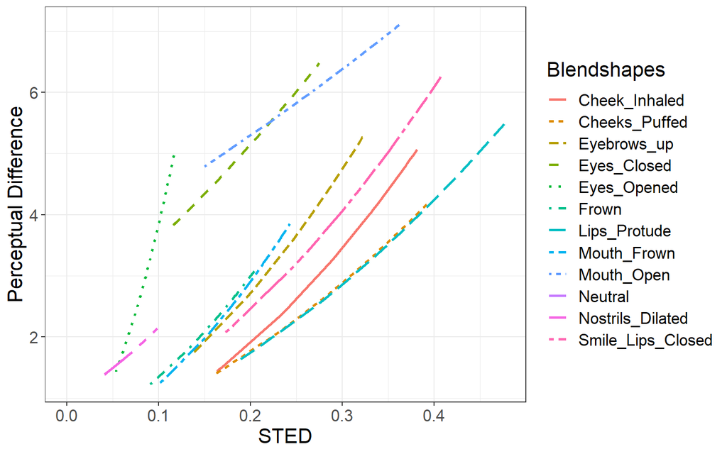

```r
m<- glm(Difference~STED*AU_Name,data=mydata,family=poisson(link="sqrt"))
ggplot(mydata,aes(STED, Difference, group=interaction(AU_Name), col=interaction(Blendshapes),linetype=interaction(AU_Name)))+
   geom_line(aes(y=m$fitted.values, colour=AU_Name, linetype=AU_Name),size=1) +
   #  geom_point(alpha = 0.8,show.legend=TRUE) +
   ylab("Perceptual Difference") +
   xlab("STED") +
   theme_bw()+
   theme(text = element_text(size = 16))+
   labs(col="Blendshapes",linetype="Blendshapes")
```

## MSE* AU* Sex* Race (Fig 4 (e))

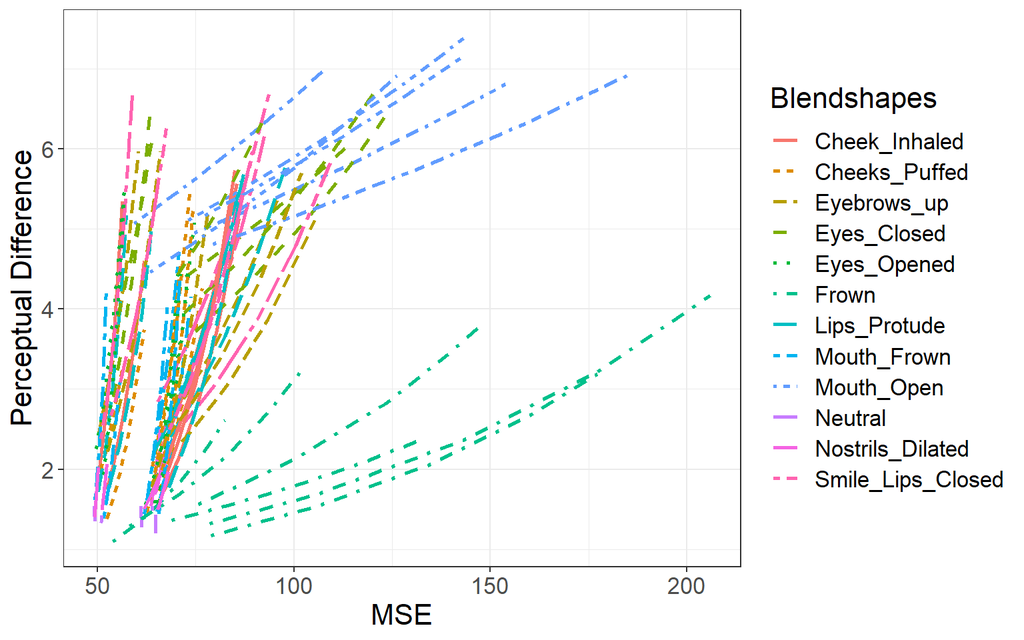

```r
m<- glm(Difference~MSE*relevel(factor(AU_Name),ref='Neutral')*Sex*Race,data=mydata,family=poisson(link="log"))
ggplot(mydata,aes(MSE, Difference, group=interaction(AU_Name,Race,Sex), col=interaction(Blendshapes),linetype=interaction(AU_Name)))+
   geom_line(aes(y=m$fitted.values, colour=AU_Name, linetype=AU_Name),size=1) +
   ylab("Perceptual Difference") +
   xlab("MSE") +
   theme_bw()+
   theme(text = element_text(size = 16))+
   labs(col="Blendshapes",linetype="Blendshapes")
```

## MSE*AU (Fig 4 (f))

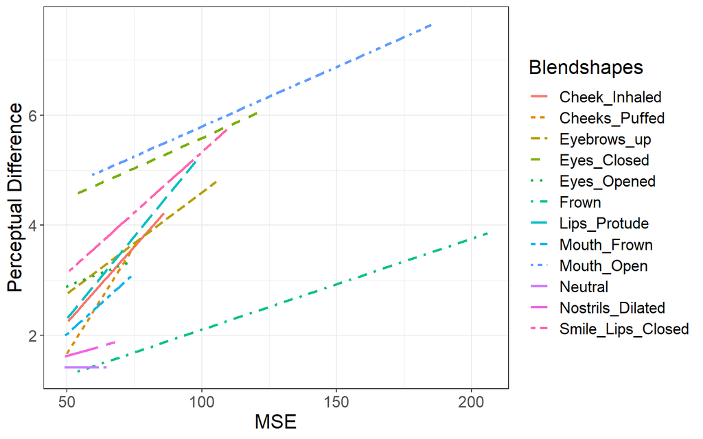

```r
m<- glm(Difference~MSE*relevel(factor(AU_Name),ref='Neutral'),data=mydata,family=poisson(link="identity"))
ggplot(mydata,aes(MSE, Difference, group=interaction(AU_Name), col=interaction(Blendshapes),linetype=interaction(AU_Name)))+
   geom_line(aes(y=m$fitted.values, colour=AU_Name, linetype=AU_Name),size=1) +
   ylab("Perceptual Difference") +
   xlab("MSE") +
   theme_bw()+
   theme(text = element_text(size = 16))+
   labs(col="Blendshapes",linetype="Blendshapes")
```

## SSIM* AU * Sex* Race (Fig 4 (g))

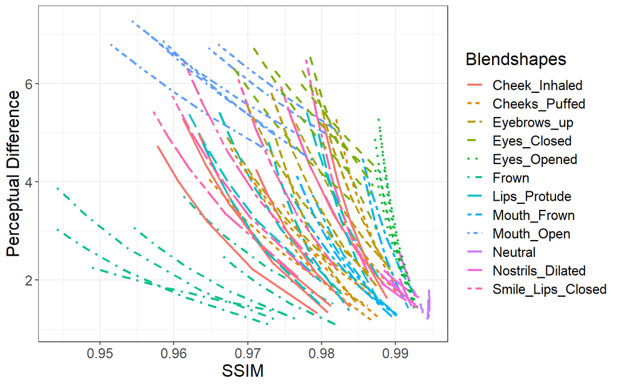

```r
m<- glm(Difference~SSIM*relevel(factor(AU_Name),ref='Neutral')*Sex*Race,data=mydata,family=poisson(link="log"))
ggplot(mydata,aes(SSIM, Difference, group=interaction(AU_Name,Race,Sex), col=interaction(Blendshapes),linetype=interaction(AU_Name)))+
   geom_line(aes(y=m$fitted.values, colour=AU_Name, linetype=AU_Name),size=1) +
   ylab("Perceptual Difference") +
   xlab("SSIM") +
   theme_bw()+
   theme(text = element_text(size = 16))+
   labs(col="Blendshapes",linetype="Blendshapes")
```

## SSIM*AU (Fig 4 (h))

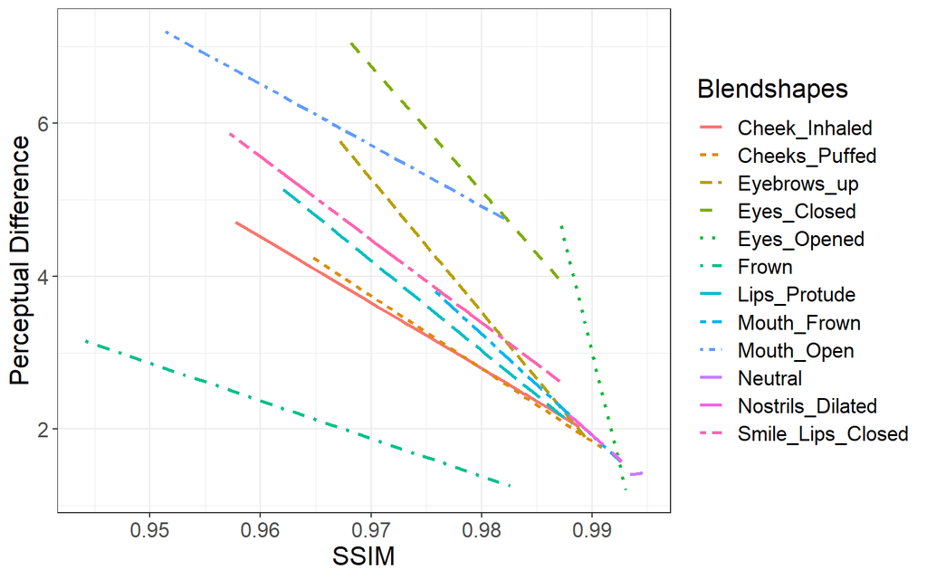

```r
m<- glm(Difference~SSIM*relevel(factor(AU_Name),ref='Neutral'),data=mydata,family=poisson(link="identity"))
ggplot(mydata,aes(SSIM, Difference, group=interaction(AU_Name), col=interaction(Blendshapes),linetype=interaction(AU_Name)))+
   geom_line(aes(y=m$fitted.values, colour=AU_Name, linetype=AU_Name),size=1) +
   ylab("Perceptual Difference") +
   xlab("SSIM") +
   theme_bw()+
   theme(text = element_text(size = 16))+
   labs(col="Blendshapes",linetype="Blendshapes")
```